# Risk Factor Analysis

## Outcome Variable

**Outcome Variable:** wast_rec90d

## Predictor Variables

**Intervention Variable:** gagebrth

**Adjustment Set:**

- arm
- sex
- W_mage
- meducyrs
- feducyrs
- hhwealth_quart
- brthmon
- W_parity
- impsan
- delta_W_mage
- delta_meducyrs
- delta_feducyrs
- delta_hhwealth_quart
- delta_brthmon
- delta_W_parity
- delta_impsan

## Stratifying Variables

The analysis was stratified on these variable(s):

- agecat
- studyid
- country

## Data Summary

| agecat | studyid | country | gagebrth | wast_rec90d | n_cell | n |
| --- | --- | --- | --- | --- | --- | --- |
| 0-24 months | ki1000108-CMC-V-BCS-2002 | INDIA | Full or late term | 0 | 68 | 299 |
| 0-24 months | ki1000108-CMC-V-BCS-2002 | INDIA | Full or late term | 1 | 117 | 299 |
| 0-24 months | ki1000108-CMC-V-BCS-2002 | INDIA | Preterm | 0 | 21 | 299 |
| 0-24 months | ki1000108-CMC-V-BCS-2002 | INDIA | Preterm | 1 | 28 | 299 |
| 0-24 months | ki1000108-CMC-V-BCS-2002 | INDIA | Early term | 0 | 21 | 299 |
| 0-24 months | ki1000108-CMC-V-BCS-2002 | INDIA | Early term | 1 | 44 | 299 |
| 0-24 months | ki1000108-IRC | INDIA | Full or late term | 0 | 92 | 382 |
| 0-24 months | ki1000108-IRC | INDIA | Full or late term | 1 | 134 | 382 |
| 0-24 months | ki1000108-IRC | INDIA | Preterm | 0 | 24 | 382 |
| 0-24 months | ki1000108-IRC | INDIA | Preterm | 1 | 29 | 382 |
| 0-24 months | ki1000108-IRC | INDIA | Early term | 0 | 39 | 382 |
| 0-24 months | ki1000108-IRC | INDIA | Early term | 1 | 64 | 382 |
| 0-24 months | ki1000109-EE | PAKISTAN | Full or late term | 0 | 5 | 323 |
| 0-24 months | ki1000109-EE | PAKISTAN | Full or late term | 1 | 1 | 323 |
| 0-24 months | ki1000109-EE | PAKISTAN | Preterm | 0 | 134 | 323 |
| 0-24 months | ki1000109-EE | PAKISTAN | Preterm | 1 | 143 | 323 |
| 0-24 months | ki1000109-EE | PAKISTAN | Early term | 0 | 21 | 323 |
| 0-24 months | ki1000109-EE | PAKISTAN | Early term | 1 | 19 | 323 |
| 0-24 months | ki1017093c-NIH-Crypto | BANGLADESH | Full or late term | 0 | 16 | 310 |
| 0-24 months | ki1017093c-NIH-Crypto | BANGLADESH | Full or late term | 1 | 25 | 310 |
| 0-24 months | ki1017093c-NIH-Crypto | BANGLADESH | Preterm | 0 | 57 | 310 |
| 0-24 months | ki1017093c-NIH-Crypto | BANGLADESH | Preterm | 1 | 92 | 310 |
| 0-24 months | ki1017093c-NIH-Crypto | BANGLADESH | Early term | 0 | 44 | 310 |
| 0-24 months | ki1017093c-NIH-Crypto | BANGLADESH | Early term | 1 | 76 | 310 |
| 0-24 months | ki1066203-TanzaniaChild2 | TANZANIA, UNITED REPUBLIC OF | Full or late term | 0 | 128 | 666 |
| 0-24 months | ki1066203-TanzaniaChild2 | TANZANIA, UNITED REPUBLIC OF | Full or late term | 1 | 247 | 666 |
| 0-24 months | ki1066203-TanzaniaChild2 | TANZANIA, UNITED REPUBLIC OF | Preterm | 0 | 52 | 666 |
| 0-24 months | ki1066203-TanzaniaChild2 | TANZANIA, UNITED REPUBLIC OF | Preterm | 1 | 77 | 666 |
| 0-24 months | ki1066203-TanzaniaChild2 | TANZANIA, UNITED REPUBLIC OF | Early term | 0 | 67 | 666 |
| 0-24 months | ki1066203-TanzaniaChild2 | TANZANIA, UNITED REPUBLIC OF | Early term | 1 | 95 | 666 |

[output cut: 168 more lines]

The following strata were considered:

- agecat: 0-24 months, studyid: ki1000108-CMC-V-BCS-2002, country: INDIA
- agecat: 0-24 months, studyid: ki1000108-IRC, country: INDIA
- agecat: 0-24 months, studyid: ki1000109-EE, country: PAKISTAN
- agecat: 0-24 months, studyid: ki1017093c-NIH-Crypto, country: BANGLADESH
- agecat: 0-24 months, studyid: ki1066203-TanzaniaChild2, country: TANZANIA, UNITED REPUBLIC OF
- agecat: 0-24 months, studyid: ki1101329-Keneba, country: GAMBIA
- agecat: 0-24 months, studyid: ki1119695-PROBIT, country: BELARUS
- agecat: 0-24 months, studyid: ki1135781-COHORTS, country: GUATEMALA
- agecat: 0-24 months, studyid: ki1135781-COHORTS, country: INDIA
- agecat: 0-24 months, studyid: ki1135781-COHORTS, country: PHILIPPINES
- agecat: 0-24 months, studyid: kiGH5241-JiVitA-3, country: BANGLADESH
- agecat: 0-6 months, studyid: ki1000108-CMC-V-BCS-2002, country: INDIA
- agecat: 0-6 months, studyid: ki1000108-IRC, country: INDIA
- agecat: 0-6 months, studyid: ki1000109-EE, country: PAKISTAN
- agecat: 0-6 months, studyid: ki1017093c-NIH-Crypto, country: BANGLADESH
- agecat: 0-6 months, studyid: ki1066203-TanzaniaChild2, country: TANZANIA, UNITED REPUBLIC OF
- agecat: 0-6 months, studyid: ki1101329-Keneba, country: GAMBIA
- agecat: 0-6 months, studyid: ki1119695-PROBIT, country: BELARUS
- agecat: 0-6 months, studyid: ki1135781-COHORTS, country: GUATEMALA
- agecat: 0-6 months, studyid: ki1135781-COHORTS, country: INDIA
- agecat: 0-6 months, studyid: ki1135781-COHORTS, country: PHILIPPINES
- agecat: 0-6 months, studyid: kiGH5241-JiVitA-3, country: BANGLADESH
- agecat: 6-24 months, studyid: ki1000108-CMC-V-BCS-2002, country: INDIA
- agecat: 6-24 months, studyid: ki1000108-IRC, country: INDIA
- agecat: 6-24 months, studyid: ki1000109-EE, country: PAKISTAN
- agecat: 6-24 months, studyid: ki1017093c-NIH-Crypto, country: BANGLADESH
- agecat: 6-24 months, studyid: ki1066203-TanzaniaChild2, country: TANZANIA, UNITED REPUBLIC OF
- agecat: 6-24 months, studyid: ki1101329-Keneba, country: GAMBIA
- agecat: 6-24 months, studyid: ki1119695-PROBIT, country: BELARUS
- agecat: 6-24 months, studyid: ki1135781-COHORTS, country: GUATEMALA
- agecat: 6-24 months, studyid: ki1135781-COHORTS, country: INDIA
- agecat: 6-24 months, studyid: ki1135781-COHORTS, country: PHILIPPINES
- agecat: 6-24 months, studyid: kiGH5241-JiVitA-3, country: BANGLADESH

### Dropped Strata

Some strata were dropped due to rare outcomes:

- agecat: 0-24 months, studyid: ki1000109-EE, country: PAKISTAN
- agecat: 0-6 months, studyid: ki1000109-EE, country: PAKISTAN
- agecat: 0-6 months, studyid: ki1017093c-NIH-Crypto, country: BANGLADESH
- agecat: 6-24 months, studyid: ki1000109-EE, country: PAKISTAN
- agecat: 6-24 months, studyid: ki1017093c-NIH-Crypto, country: BANGLADESH
- agecat: 6-24 months, studyid: ki1119695-PROBIT, country: BELARUS
- agecat: 6-24 months, studyid: ki1135781-COHORTS, country: GUATEMALA
- agecat: 6-24 months, studyid: ki1135781-COHORTS, country: INDIA
- agecat: 6-24 months, studyid: kiGH5241-JiVitA-3, country: BANGLADESH

## Methods Detail

We’re interested in the causal parameters $E[Y_a]$ for all values of $a \in \mathcal{A}$. These parameters represent the mean outcome if, possibly contrary to fact, we intervened to set all units to have $A=a$. Under the randomization and positivity assumptions, these are identified by the statistical parameters $\psi_a=E_W[E_{Y|A,W}(Y|A=a,W)]$. In addition, we’re interested in the mean of $Y$, $E[Y]$ under no intervention (the observed mean). We will estimate these parameters by using SuperLearner to fit the relevant likelihood factors – $E_{Y|A,W}(Y|A=a,W)$ and $p(A=a|W)$, and then updating our likelihood fit using a joint TMLE.

For unadjusted analyses ($W=\{\}$), initial likelihoods were estimated using Lrnr_glm to estimate the simple $E(Y|A)$ and Lrnr_mean to estimate $p(A)$. For adjusted analyses, a small library containing Lrnr_glmnet, Lrnr_xgboost, and Lrnr_mean was used.

Having estimated these parameters, we will then use the delta method to estimate relative risks and attributable risks relative to a prespecified baseline level of $A$.

# Results Detail

## Results Plots

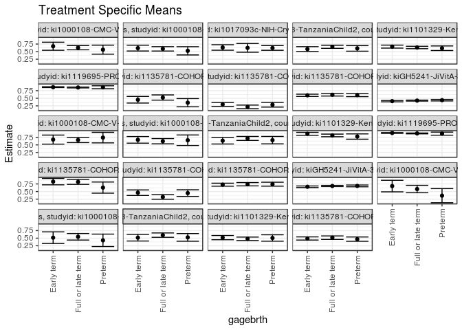

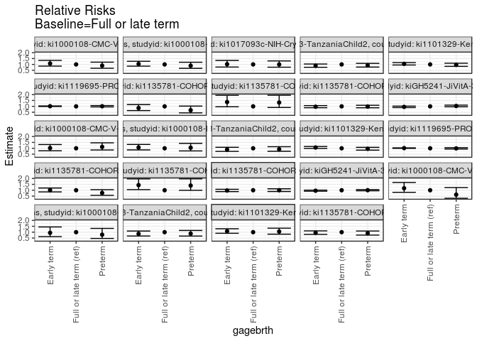

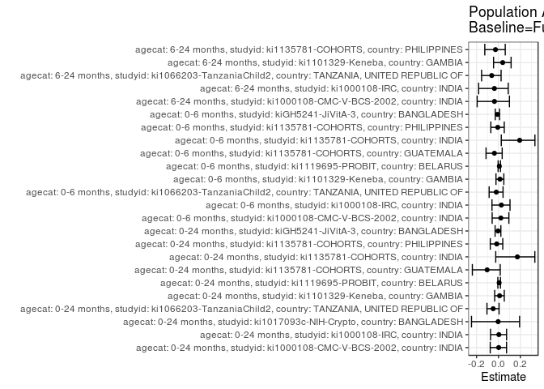

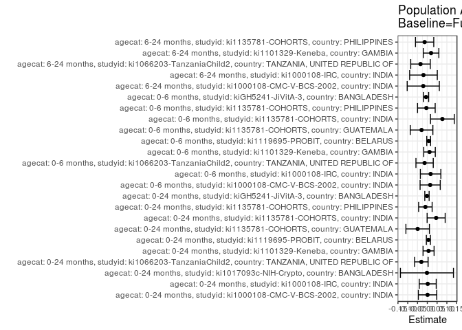

## Results Table

### Parameter: TSM

| agecat | studyid | country | intervention_level | baseline_level | estimate | ci_lower | ci_upper |
| --- | --- | --- | --- | --- | --- | --- | --- |
| 0-24 months | ki1000108-CMC-V-BCS-2002 | INDIA | Full or late term | NA | 0.6308212 | 0.5598853 | 0.7017572 |
| 0-24 months | ki1000108-CMC-V-BCS-2002 | INDIA | Preterm | NA | 0.5645219 | 0.4154271 | 0.7136166 |
| 0-24 months | ki1000108-CMC-V-BCS-2002 | INDIA | Early term | NA | 0.6779294 | 0.5455656 | 0.8102933 |
| 0-24 months | ki1000108-IRC | INDIA | Full or late term | NA | 0.5920599 | 0.5198093 | 0.6643104 |
| 0-24 months | ki1000108-IRC | INDIA | Preterm | NA | 0.5263726 | 0.3901051 | 0.6626401 |
| 0-24 months | ki1000108-IRC | INDIA | Early term | NA | 0.6160130 | 0.5204179 | 0.7116081 |
| 0-24 months | ki1017093c-NIH-Crypto | BANGLADESH | Full or late term | NA | 0.6243670 | 0.4800679 | 0.7686661 |
| 0-24 months | ki1017093c-NIH-Crypto | BANGLADESH | Preterm | NA | 0.6219894 | 0.5444766 | 0.6995023 |
| 0-24 months | ki1017093c-NIH-Crypto | BANGLADESH | Early term | NA | 0.6369409 | 0.5463623 | 0.7275196 |
| 0-24 months | ki1066203-TanzaniaChild2 | TANZANIA, UNITED REPUBLIC OF | Full or late term | NA | 0.6595674 | 0.6086351 | 0.7104997 |
| 0-24 months | ki1066203-TanzaniaChild2 | TANZANIA, UNITED REPUBLIC OF | Preterm | NA | 0.6067659 | 0.5148547 | 0.6986771 |
| 0-24 months | ki1066203-TanzaniaChild2 | TANZANIA, UNITED REPUBLIC OF | Early term | NA | 0.5841008 | 0.5041108 | 0.6640907 |
| 0-24 months | ki1101329-Keneba | GAMBIA | Full or late term | NA | 0.6364319 | 0.5970911 | 0.6757727 |
| 0-24 months | ki1101329-Keneba | GAMBIA | Preterm | NA | 0.6121157 | 0.5369220 | 0.6873094 |
| 0-24 months | ki1101329-Keneba | GAMBIA | Early term | NA | 0.6654444 | 0.6165412 | 0.7143475 |
| 0-24 months | ki1119695-PROBIT | BELARUS | Full or late term | NA | 0.8557214 | 0.8409043 | 0.8705385 |
| 0-24 months | ki1119695-PROBIT | BELARUS | Preterm | NA | 0.8630756 | 0.8146946 | 0.9114566 |
| 0-24 months | ki1119695-PROBIT | BELARUS | Early term | NA | 0.8659337 | 0.8513675 | 0.8804999 |
| 0-24 months | ki1135781-COHORTS | GUATEMALA | Full or late term | NA | 0.5242992 | 0.4384353 | 0.6101630 |
| 0-24 months | ki1135781-COHORTS | GUATEMALA | Preterm | NA | 0.3537164 | 0.2183000 | 0.4891329 |
| 0-24 months | ki1135781-COHORTS | GUATEMALA | Early term | NA | 0.4507381 | 0.3412825 | 0.5601936 |
| 0-24 months | ki1135781-COHORTS | INDIA | Full or late term | NA | 0.2167393 | 0.1578164 | 0.2756623 |
| 0-24 months | ki1135781-COHORTS | INDIA | Preterm | NA | 0.2871879 | 0.2096444 | 0.3647315 |
| 0-24 months | ki1135781-COHORTS | INDIA | Early term | NA | 0.2962859 | 0.2310833 | 0.3614885 |
| 0-24 months | ki1135781-COHORTS | PHILIPPINES | Full or late term | NA | 0.6157733 | 0.5727846 | 0.6587621 |
| 0-24 months | ki1135781-COHORTS | PHILIPPINES | Preterm | NA | 0.6045053 | 0.5543980 | 0.6546127 |
| 0-24 months | ki1135781-COHORTS | PHILIPPINES | Early term | NA | 0.5971503 | 0.5595459 | 0.6347547 |
| 0-24 months | kiGH5241-JiVitA-3 | BANGLADESH | Full or late term | NA | 0.4232781 | 0.4074227 | 0.4391336 |
| 0-24 months | kiGH5241-JiVitA-3 | BANGLADESH | Preterm | NA | 0.4365012 | 0.4114041 | 0.4615982 |
| 0-24 months | kiGH5241-JiVitA-3 | BANGLADESH | Early term | NA | 0.4045997 | 0.3829514 | 0.4262480 |
| 0-6 months | ki1000108-CMC-V-BCS-2002 | INDIA | Full or late term | NA | 0.6610169 | 0.5757140 | 0.7463199 |
| 0-6 months | ki1000108-CMC-V-BCS-2002 | INDIA | Preterm | NA | 0.7407407 | 0.5666423 | 0.9148392 |
| 0-6 months | ki1000108-CMC-V-BCS-2002 | INDIA | Early term | NA | 0.6750000 | 0.5258441 | 0.8241559 |
| 0-6 months | ki1000108-IRC | INDIA | Full or late term | NA | 0.6222222 | 0.5361698 | 0.7082747 |
| 0-6 months | ki1000108-IRC | INDIA | Preterm | NA | 0.6538462 | 0.4797295 | 0.8279628 |
| 0-6 months | ki1000108-IRC | INDIA | Early term | NA | 0.6666667 | 0.5568093 | 0.7765240 |
| 0-6 months | ki1066203-TanzaniaChild2 | TANZANIA, UNITED REPUBLIC OF | Full or late term | NA | 0.7131632 | 0.6470477 | 0.7792788 |
| 0-6 months | ki1066203-TanzaniaChild2 | TANZANIA, UNITED REPUBLIC OF | Preterm | NA | 0.6566496 | 0.5343340 | 0.7789651 |
| 0-6 months | ki1066203-TanzaniaChild2 | TANZANIA, UNITED REPUBLIC OF | Early term | NA | 0.6382234 | 0.5302790 | 0.7461678 |
| 0-6 months | ki1101329-Keneba | GAMBIA | Full or late term | NA | 0.8120929 | 0.7683605 | 0.8558254 |
| 0-6 months | ki1101329-Keneba | GAMBIA | Preterm | NA | 0.7754122 | 0.6878187 | 0.8630056 |
| 0-6 months | ki1101329-Keneba | GAMBIA | Early term | NA | 0.8653108 | 0.8169268 | 0.9136948 |
| 0-6 months | ki1119695-PROBIT | BELARUS | Full or late term | NA | 0.8785301 | 0.8645183 | 0.8925419 |
| 0-6 months | ki1119695-PROBIT | BELARUS | Preterm | NA | 0.8707623 | 0.8203728 | 0.9211517 |
| 0-6 months | ki1119695-PROBIT | BELARUS | Early term | NA | 0.8929232 | 0.8792400 | 0.9066064 |
| 0-6 months | ki1135781-COHORTS | GUATEMALA | Full or late term | NA | 0.8181818 | 0.7368393 | 0.8995243 |
| 0-6 months | ki1135781-COHORTS | GUATEMALA | Preterm | NA | 0.6296296 | 0.4457667 | 0.8134926 |
| 0-6 months | ki1135781-COHORTS | GUATEMALA | Early term | NA | 0.8260870 | 0.7207224 | 0.9314515 |
| 0-6 months | ki1135781-COHORTS | INDIA | Full or late term | NA | 0.3211410 | 0.2447311 | 0.3975510 |
| 0-6 months | ki1135781-COHORTS | INDIA | Preterm | NA | 0.4484090 | 0.3384696 | 0.5583483 |
| 0-6 months | ki1135781-COHORTS | INDIA | Early term | NA | 0.4616675 | 0.3702865 | 0.5530486 |
| 0-6 months | ki1135781-COHORTS | PHILIPPINES | Full or late term | NA | 0.7414081 | 0.6866906 | 0.7961257 |
| 0-6 months | ki1135781-COHORTS | PHILIPPINES | Preterm | NA | 0.7428754 | 0.6781815 | 0.8075694 |
| 0-6 months | ki1135781-COHORTS | PHILIPPINES | Early term | NA | 0.7254882 | 0.6763589 | 0.7746174 |
| 0-6 months | kiGH5241-JiVitA-3 | BANGLADESH | Full or late term | NA | 0.6832742 | 0.6642931 | 0.7022553 |
| 0-6 months | kiGH5241-JiVitA-3 | BANGLADESH | Preterm | NA | 0.6858946 | 0.6565953 | 0.7151939 |
| 0-6 months | kiGH5241-JiVitA-3 | BANGLADESH | Early term | NA | 0.6565544 | 0.6296851 | 0.6834237 |
| 6-24 months | ki1000108-CMC-V-BCS-2002 | INDIA | Full or late term | NA | 0.5820896 | 0.4594727 | 0.7047064 |
| 6-24 months | ki1000108-CMC-V-BCS-2002 | INDIA | Preterm | NA | 0.3636364 | 0.1308138 | 0.5964590 |
| 6-24 months | ki1000108-CMC-V-BCS-2002 | INDIA | Early term | NA | 0.6800000 | 0.4890151 | 0.8709849 |
| 6-24 months | ki1000108-IRC | INDIA | Full or late term | NA | 0.5458918 | 0.4376822 | 0.6541015 |
| 6-24 months | ki1000108-IRC | INDIA | Preterm | NA | 0.4290213 | 0.2241696 | 0.6338731 |
| 6-24 months | ki1000108-IRC | INDIA | Early term | NA | 0.5162003 | 0.3238934 | 0.7085073 |
| 6-24 months | ki1066203-TanzaniaChild2 | TANZANIA, UNITED REPUBLIC OF | Full or late term | NA | 0.6004626 | 0.5286854 | 0.6722398 |
| 6-24 months | ki1066203-TanzaniaChild2 | TANZANIA, UNITED REPUBLIC OF | Preterm | NA | 0.5254959 | 0.3990314 | 0.6519604 |
| 6-24 months | ki1066203-TanzaniaChild2 | TANZANIA, UNITED REPUBLIC OF | Early term | NA | 0.5158540 | 0.4064529 | 0.6252551 |
| 6-24 months | ki1101329-Keneba | GAMBIA | Full or late term | NA | 0.4793430 | 0.4230814 | 0.5356046 |
| 6-24 months | ki1101329-Keneba | GAMBIA | Preterm | NA | 0.5059748 | 0.4001502 | 0.6117995 |
| 6-24 months | ki1101329-Keneba | GAMBIA | Early term | NA | 0.5178129 | 0.4487015 | 0.5869242 |
| 6-24 months | ki1135781-COHORTS | PHILIPPINES | Full or late term | NA | 0.5152658 | 0.4571671 | 0.5733645 |
| 6-24 months | ki1135781-COHORTS | PHILIPPINES | Preterm | NA | 0.4681339 | 0.3970936 | 0.5391743 |
| 6-24 months | ki1135781-COHORTS | PHILIPPINES | Early term | NA | 0.4894381 | 0.4372549 | 0.5416213 |

### Parameter: E(Y)

| agecat | studyid | country | intervention_level | baseline_level | estimate | ci_lower | ci_upper |
| --- | --- | --- | --- | --- | --- | --- | --- |
| 0-24 months | ki1000108-CMC-V-BCS-2002 | INDIA | NA | NA | 0.6321070 | 0.5744109 | 0.6898031 |
| 0-24 months | ki1000108-IRC | INDIA | NA | NA | 0.5942408 | 0.5412823 | 0.6471994 |
| 0-24 months | ki1017093c-NIH-Crypto | BANGLADESH | NA | NA | 0.6225806 | 0.5684562 | 0.6767051 |
| 0-24 months | ki1066203-TanzaniaChild2 | TANZANIA, UNITED REPUBLIC OF | NA | NA | 0.6291291 | 0.5901846 | 0.6680736 |
| 0-24 months | ki1101329-Keneba | GAMBIA | NA | NA | 0.6429143 | 0.6145621 | 0.6712666 |
| 0-24 months | ki1119695-PROBIT | BELARUS | NA | NA | 0.8612051 | 0.8511051 | 0.8713052 |
| 0-24 months | ki1135781-COHORTS | GUATEMALA | NA | NA | 0.4750000 | 0.4147665 | 0.5352335 |
| 0-24 months | ki1135781-COHORTS | INDIA | NA | NA | 0.2619503 | 0.2237649 | 0.3001357 |
| 0-24 months | ki1135781-COHORTS | PHILIPPINES | NA | NA | 0.6059701 | 0.5813402 | 0.6306001 |
| 0-24 months | kiGH5241-JiVitA-3 | BANGLADESH | NA | NA | 0.4215278 | 0.4101272 | 0.4329284 |
| 0-6 months | ki1000108-CMC-V-BCS-2002 | INDIA | NA | NA | 0.6756757 | 0.6074152 | 0.7439361 |
| 0-6 months | ki1000108-IRC | INDIA | NA | NA | 0.6391304 | 0.5756367 | 0.7026242 |
| 0-6 months | ki1066203-TanzaniaChild2 | TANZANIA, UNITED REPUBLIC OF | NA | NA | 0.6993671 | 0.6481378 | 0.7505964 |
| 0-6 months | ki1101329-Keneba | GAMBIA | NA | NA | 0.8234234 | 0.7927195 | 0.8541273 |
| 0-6 months | ki1119695-PROBIT | BELARUS | NA | NA | 0.8855266 | 0.8758983 | 0.8951550 |
| 0-6 months | ki1135781-COHORTS | GUATEMALA | NA | NA | 0.7888199 | 0.7258783 | 0.8517615 |
| 0-6 months | ki1135781-COHORTS | INDIA | NA | NA | 0.3982558 | 0.3464489 | 0.4500628 |
| 0-6 months | ki1135781-COHORTS | PHILIPPINES | NA | NA | 0.7365591 | 0.7047881 | 0.7683302 |
| 0-6 months | kiGH5241-JiVitA-3 | BANGLADESH | NA | NA | 0.6768510 | 0.6631621 | 0.6905400 |
| 6-24 months | ki1000108-CMC-V-BCS-2002 | INDIA | NA | NA | 0.5614035 | 0.4645960 | 0.6582110 |
| 6-24 months | ki1000108-IRC | INDIA | NA | NA | 0.5263158 | 0.4415211 | 0.6111105 |
| 6-24 months | ki1066203-TanzaniaChild2 | TANZANIA, UNITED REPUBLIC OF | NA | NA | 0.5657143 | 0.5118874 | 0.6195411 |
| 6-24 months | ki1101329-Keneba | GAMBIA | NA | NA | 0.4985591 | 0.4587425 | 0.5383757 |
| 6-24 months | ki1135781-COHORTS | PHILIPPINES | NA | NA | 0.5016112 | 0.4676556 | 0.5355667 |

### Parameter: RR

| agecat | studyid | country | intervention_level | baseline_level | estimate | ci_lower | ci_upper |
| --- | --- | --- | --- | --- | --- | --- | --- |
| 0-24 months | ki1000108-CMC-V-BCS-2002 | INDIA | Full or late term | Full or late term | 1.0000000 | 1.0000000 | 1.000000 |
| 0-24 months | ki1000108-CMC-V-BCS-2002 | INDIA | Preterm | Full or late term | 0.8948999 | 0.6718714 | 1.191963 |
| 0-24 months | ki1000108-CMC-V-BCS-2002 | INDIA | Early term | Full or late term | 1.0746776 | 0.8588041 | 1.344814 |
| 0-24 months | ki1000108-IRC | INDIA | Full or late term | Full or late term | 1.0000000 | 1.0000000 | 1.000000 |
| 0-24 months | ki1000108-IRC | INDIA | Preterm | Full or late term | 0.8890530 | 0.6674839 | 1.184171 |
| 0-24 months | ki1000108-IRC | INDIA | Early term | Full or late term | 1.0404572 | 0.8538763 | 1.267808 |
| 0-24 months | ki1017093c-NIH-Crypto | BANGLADESH | Full or late term | Full or late term | 1.0000000 | 1.0000000 | 1.000000 |
| 0-24 months | ki1017093c-NIH-Crypto | BANGLADESH | Preterm | Full or late term | 0.9961920 | 0.7657429 | 1.295994 |
| 0-24 months | ki1017093c-NIH-Crypto | BANGLADESH | Early term | Full or late term | 1.0201387 | 0.7772206 | 1.338980 |
| 0-24 months | ki1066203-TanzaniaChild2 | TANZANIA, UNITED REPUBLIC OF | Full or late term | Full or late term | 1.0000000 | 1.0000000 | 1.000000 |
| 0-24 months | ki1066203-TanzaniaChild2 | TANZANIA, UNITED REPUBLIC OF | Preterm | Full or late term | 0.9199452 | 0.7761210 | 1.090422 |
| 0-24 months | ki1066203-TanzaniaChild2 | TANZANIA, UNITED REPUBLIC OF | Early term | Full or late term | 0.8855816 | 0.7568380 | 1.036225 |
| 0-24 months | ki1101329-Keneba | GAMBIA | Full or late term | Full or late term | 1.0000000 | 1.0000000 | 1.000000 |
| 0-24 months | ki1101329-Keneba | GAMBIA | Preterm | Full or late term | 0.9617929 | 0.8385861 | 1.103102 |
| 0-24 months | ki1101329-Keneba | GAMBIA | Early term | Full or late term | 1.0455862 | 0.9500357 | 1.150747 |
| 0-24 months | ki1119695-PROBIT | BELARUS | Full or late term | Full or late term | 1.0000000 | 1.0000000 | 1.000000 |
| 0-24 months | ki1119695-PROBIT | BELARUS | Preterm | Full or late term | 1.0085941 | 0.9511210 | 1.069540 |
| 0-24 months | ki1119695-PROBIT | BELARUS | Early term | Full or late term | 1.0119341 | 0.9877940 | 1.036664 |
| 0-24 months | ki1135781-COHORTS | GUATEMALA | Full or late term | Full or late term | 1.0000000 | 1.0000000 | 1.000000 |
| 0-24 months | ki1135781-COHORTS | GUATEMALA | Preterm | Full or late term | 0.6746461 | 0.4449914 | 1.022823 |
| 0-24 months | ki1135781-COHORTS | GUATEMALA | Early term | Full or late term | 0.8596963 | 0.6415701 | 1.151983 |
| 0-24 months | ki1135781-COHORTS | INDIA | Full or late term | Full or late term | 1.0000000 | 1.0000000 | 1.000000 |
| 0-24 months | ki1135781-COHORTS | INDIA | Preterm | Full or late term | 1.3250385 | 0.9033692 | 1.943532 |
| 0-24 months | ki1135781-COHORTS | INDIA | Early term | Full or late term | 1.3670150 | 0.9649383 | 1.936632 |
| 0-24 months | ki1135781-COHORTS | PHILIPPINES | Full or late term | Full or late term | 1.0000000 | 1.0000000 | 1.000000 |
| 0-24 months | ki1135781-COHORTS | PHILIPPINES | Preterm | Full or late term | 0.9817010 | 0.8808899 | 1.094049 |
| 0-24 months | ki1135781-COHORTS | PHILIPPINES | Early term | Full or late term | 0.9697567 | 0.8828076 | 1.065270 |
| 0-24 months | kiGH5241-JiVitA-3 | BANGLADESH | Full or late term | Full or late term | 1.0000000 | 1.0000000 | 1.000000 |
| 0-24 months | kiGH5241-JiVitA-3 | BANGLADESH | Preterm | Full or late term | 1.0312396 | 0.9628761 | 1.104457 |
| 0-24 months | kiGH5241-JiVitA-3 | BANGLADESH | Early term | Full or late term | 0.9558719 | 0.8954963 | 1.020318 |
| 0-6 months | ki1000108-CMC-V-BCS-2002 | INDIA | Full or late term | Full or late term | 1.0000000 | 1.0000000 | 1.000000 |
| 0-6 months | ki1000108-CMC-V-BCS-2002 | INDIA | Preterm | Full or late term | 1.1206078 | 0.8570471 | 1.465219 |
| 0-6 months | ki1000108-CMC-V-BCS-2002 | INDIA | Early term | Full or late term | 1.0211538 | 0.7906029 | 1.318937 |
| 0-6 months | ki1000108-IRC | INDIA | Full or late term | Full or late term | 1.0000000 | 1.0000000 | 1.000000 |
| 0-6 months | ki1000108-IRC | INDIA | Preterm | Full or late term | 1.0508242 | 0.7784047 | 1.418583 |
| 0-6 months | ki1000108-IRC | INDIA | Early term | Full or late term | 1.0714286 | 0.8640328 | 1.328606 |
| 0-6 months | ki1066203-TanzaniaChild2 | TANZANIA, UNITED REPUBLIC OF | Full or late term | Full or late term | 1.0000000 | 1.0000000 | 1.000000 |
| 0-6 months | ki1066203-TanzaniaChild2 | TANZANIA, UNITED REPUBLIC OF | Preterm | Full or late term | 0.9207564 | 0.7472192 | 1.134596 |
| 0-6 months | ki1066203-TanzaniaChild2 | TANZANIA, UNITED REPUBLIC OF | Early term | Full or late term | 0.8949191 | 0.7376860 | 1.085665 |
| 0-6 months | ki1101329-Keneba | GAMBIA | Full or late term | Full or late term | 1.0000000 | 1.0000000 | 1.000000 |
| 0-6 months | ki1101329-Keneba | GAMBIA | Preterm | Full or late term | 0.9548318 | 0.8432294 | 1.081205 |
| 0-6 months | ki1101329-Keneba | GAMBIA | Early term | Full or late term | 1.0655317 | 0.9866902 | 1.150673 |
| 0-6 months | ki1119695-PROBIT | BELARUS | Full or late term | Full or late term | 1.0000000 | 1.0000000 | 1.000000 |
| 0-6 months | ki1119695-PROBIT | BELARUS | Preterm | Full or late term | 0.9911582 | 0.9334127 | 1.052476 |
| 0-6 months | ki1119695-PROBIT | BELARUS | Early term | Full or late term | 1.0163832 | 0.9941505 | 1.039113 |
| 0-6 months | ki1135781-COHORTS | GUATEMALA | Full or late term | Full or late term | 1.0000000 | 1.0000000 | 1.000000 |
| 0-6 months | ki1135781-COHORTS | GUATEMALA | Preterm | Full or late term | 0.7695473 | 0.5652821 | 1.047624 |
| 0-6 months | ki1135781-COHORTS | GUATEMALA | Early term | Full or late term | 1.0096618 | 0.8589016 | 1.186885 |
| 0-6 months | ki1135781-COHORTS | INDIA | Full or late term | Full or late term | 1.0000000 | 1.0000000 | 1.000000 |
| 0-6 months | ki1135781-COHORTS | INDIA | Preterm | Full or late term | 1.3962992 | 0.9919015 | 1.965569 |
| 0-6 months | ki1135781-COHORTS | INDIA | Early term | Full or late term | 1.4375850 | 1.0538516 | 1.961045 |
| 0-6 months | ki1135781-COHORTS | PHILIPPINES | Full or late term | Full or late term | 1.0000000 | 1.0000000 | 1.000000 |
| 0-6 months | ki1135781-COHORTS | PHILIPPINES | Preterm | Full or late term | 1.0019791 | 0.8939305 | 1.123087 |
| 0-6 months | ki1135781-COHORTS | PHILIPPINES | Early term | Full or late term | 0.9785274 | 0.8853664 | 1.081491 |
| 0-6 months | kiGH5241-JiVitA-3 | BANGLADESH | Full or late term | Full or late term | 1.0000000 | 1.0000000 | 1.000000 |
| 0-6 months | kiGH5241-JiVitA-3 | BANGLADESH | Preterm | Full or late term | 1.0038351 | 0.9539964 | 1.056278 |
| 0-6 months | kiGH5241-JiVitA-3 | BANGLADESH | Early term | Full or late term | 0.9608945 | 0.9145395 | 1.009599 |
| 6-24 months | ki1000108-CMC-V-BCS-2002 | INDIA | Full or late term | Full or late term | 1.0000000 | 1.0000000 | 1.000000 |
| 6-24 months | ki1000108-CMC-V-BCS-2002 | INDIA | Preterm | Full or late term | 0.6247086 | 0.3184160 | 1.225632 |
| 6-24 months | ki1000108-CMC-V-BCS-2002 | INDIA | Early term | Full or late term | 1.1682051 | 0.8223605 | 1.659495 |
| 6-24 months | ki1000108-IRC | INDIA | Full or late term | Full or late term | 1.0000000 | 1.0000000 | 1.000000 |
| 6-24 months | ki1000108-IRC | INDIA | Preterm | Full or late term | 0.7859090 | 0.4683391 | 1.318816 |
| 6-24 months | ki1000108-IRC | INDIA | Early term | Full or late term | 0.9456092 | 0.6200283 | 1.442155 |
| 6-24 months | ki1066203-TanzaniaChild2 | TANZANIA, UNITED REPUBLIC OF | Full or late term | Full or late term | 1.0000000 | 1.0000000 | 1.000000 |
| 6-24 months | ki1066203-TanzaniaChild2 | TANZANIA, UNITED REPUBLIC OF | Preterm | Full or late term | 0.8751517 | 0.6686490 | 1.145430 |
| 6-24 months | ki1066203-TanzaniaChild2 | TANZANIA, UNITED REPUBLIC OF | Early term | Full or late term | 0.8590942 | 0.6731852 | 1.096345 |
| 6-24 months | ki1101329-Keneba | GAMBIA | Full or late term | Full or late term | 1.0000000 | 1.0000000 | 1.000000 |
| 6-24 months | ki1101329-Keneba | GAMBIA | Preterm | Full or late term | 1.0555591 | 0.8309195 | 1.340930 |
| 6-24 months | ki1101329-Keneba | GAMBIA | Early term | Full or late term | 1.0802554 | 0.9049684 | 1.289494 |
| 6-24 months | ki1135781-COHORTS | PHILIPPINES | Full or late term | Full or late term | 1.0000000 | 1.0000000 | 1.000000 |
| 6-24 months | ki1135781-COHORTS | PHILIPPINES | Preterm | Full or late term | 0.9085290 | 0.7517841 | 1.097955 |
| 6-24 months | ki1135781-COHORTS | PHILIPPINES | Early term | Full or late term | 0.9498750 | 0.8132638 | 1.109434 |

### Parameter: PAR

| agecat | studyid | country | intervention_level | baseline_level | estimate | ci_lower | ci_upper |
| --- | --- | --- | --- | --- | --- | --- | --- |
| 0-24 months | ki1000108-CMC-V-BCS-2002 | INDIA | Full or late term | NA | 0.0012858 | -0.0458029 | 0.0483745 |
| 0-24 months | ki1000108-IRC | INDIA | Full or late term | NA | 0.0021810 | -0.0412373 | 0.0455993 |
| 0-24 months | ki1017093c-NIH-Crypto | BANGLADESH | Full or late term | NA | -0.0017864 | -0.1373561 | 0.1337833 |
| 0-24 months | ki1066203-TanzaniaChild2 | TANZANIA, UNITED REPUBLIC OF | Full or late term | NA | -0.0304383 | -0.0650005 | 0.0041239 |
| 0-24 months | ki1101329-Keneba | GAMBIA | Full or late term | NA | 0.0064824 | -0.0216911 | 0.0346559 |
| 0-24 months | ki1119695-PROBIT | BELARUS | Full or late term | NA | 0.0054837 | -0.0048944 | 0.0158619 |
| 0-24 months | ki1135781-COHORTS | GUATEMALA | Full or late term | NA | -0.0492992 | -0.1094037 | 0.0108053 |
| 0-24 months | ki1135781-COHORTS | INDIA | Full or late term | NA | 0.0452110 | -0.0009189 | 0.0913408 |
| 0-24 months | ki1135781-COHORTS | PHILIPPINES | Full or late term | NA | -0.0098032 | -0.0443427 | 0.0247363 |
| 0-24 months | kiGH5241-JiVitA-3 | BANGLADESH | Full or late term | NA | -0.0017504 | -0.0128195 | 0.0093188 |
| 0-6 months | ki1000108-CMC-V-BCS-2002 | INDIA | Full or late term | NA | 0.0146587 | -0.0368417 | 0.0661592 |
| 0-6 months | ki1000108-IRC | INDIA | Full or late term | NA | 0.0169082 | -0.0354403 | 0.0692567 |
| 0-6 months | ki1066203-TanzaniaChild2 | TANZANIA, UNITED REPUBLIC OF | Full or late term | NA | -0.0137961 | -0.0580576 | 0.0304653 |
| 0-6 months | ki1101329-Keneba | GAMBIA | Full or late term | NA | 0.0113305 | -0.0181680 | 0.0408290 |
| 0-6 months | ki1119695-PROBIT | BELARUS | Full or late term | NA | 0.0069966 | -0.0027129 | 0.0167060 |
| 0-6 months | ki1135781-COHORTS | GUATEMALA | Full or late term | NA | -0.0293619 | -0.0871996 | 0.0284757 |
| 0-6 months | ki1135781-COHORTS | INDIA | Full or late term | NA | 0.0771148 | 0.0163123 | 0.1379172 |
| 0-6 months | ki1135781-COHORTS | PHILIPPINES | Full or late term | NA | -0.0048490 | -0.0499210 | 0.0402230 |
| 0-6 months | kiGH5241-JiVitA-3 | BANGLADESH | Full or late term | NA | -0.0064231 | -0.0197995 | 0.0069532 |
| 6-24 months | ki1000108-CMC-V-BCS-2002 | INDIA | Full or late term | NA | -0.0206860 | -0.1028182 | 0.0614461 |
| 6-24 months | ki1000108-IRC | INDIA | Full or late term | NA | -0.0195760 | -0.0901900 | 0.0510380 |
| 6-24 months | ki1066203-TanzaniaChild2 | TANZANIA, UNITED REPUBLIC OF | Full or late term | NA | -0.0347483 | -0.0847888 | 0.0152922 |
| 6-24 months | ki1101329-Keneba | GAMBIA | Full or late term | NA | 0.0192161 | -0.0206084 | 0.0590405 |
| 6-24 months | ki1135781-COHORTS | PHILIPPINES | Full or late term | NA | -0.0136546 | -0.0603735 | 0.0330643 |

### Parameter: PAF

| agecat | studyid | country | intervention_level | baseline_level | estimate | ci_lower | ci_upper |
| --- | --- | --- | --- | --- | --- | --- | --- |
| 0-24 months | ki1000108-CMC-V-BCS-2002 | INDIA | Full or late term | NA | 0.0020341 | -0.0752929 | 0.0738004 |
| 0-24 months | ki1000108-IRC | INDIA | Full or late term | NA | 0.0036702 | -0.0721822 | 0.0741563 |
| 0-24 months | ki1017093c-NIH-Crypto | BANGLADESH | Full or late term | NA | -0.0028693 | -0.2460829 | 0.1928733 |
| 0-24 months | ki1066203-TanzaniaChild2 | TANZANIA, UNITED REPUBLIC OF | Full or late term | NA | -0.0483816 | -0.1050060 | 0.0053411 |
| 0-24 months | ki1101329-Keneba | GAMBIA | Full or late term | NA | 0.0100829 | -0.0347109 | 0.0529375 |
| 0-24 months | ki1119695-PROBIT | BELARUS | Full or late term | NA | 0.0063675 | -0.0057603 | 0.0183491 |
| 0-24 months | ki1135781-COHORTS | GUATEMALA | Full or late term | NA | -0.1037878 | -0.2383594 | 0.0161601 |
| 0-24 months | ki1135781-COHORTS | INDIA | Full or late term | NA | 0.1725937 | -0.0248638 | 0.3320076 |
| 0-24 months | ki1135781-COHORTS | PHILIPPINES | Full or late term | NA | -0.0161777 | -0.0747895 | 0.0392378 |
| 0-24 months | kiGH5241-JiVitA-3 | BANGLADESH | Full or late term | NA | -0.0041524 | -0.0307591 | 0.0217675 |
| 0-6 months | ki1000108-CMC-V-BCS-2002 | INDIA | Full or late term | NA | 0.0216949 | -0.0575958 | 0.0950410 |
| 0-6 months | ki1000108-IRC | INDIA | Full or late term | NA | 0.0264550 | -0.0593125 | 0.1052784 |
| 0-6 months | ki1066203-TanzaniaChild2 | TANZANIA, UNITED REPUBLIC OF | Full or late term | NA | -0.0197266 | -0.0851091 | 0.0417163 |
| 0-6 months | ki1101329-Keneba | GAMBIA | Full or late term | NA | 0.0137602 | -0.0227556 | 0.0489723 |
| 0-6 months | ki1119695-PROBIT | BELARUS | Full or late term | NA | 0.0079010 | -0.0031291 | 0.0188098 |
| 0-6 months | ki1135781-COHORTS | GUATEMALA | Full or late term | NA | -0.0372226 | -0.1135640 | 0.0338851 |
| 0-6 months | ki1135781-COHORTS | INDIA | Full or late term | NA | 0.1936313 | 0.0256593 | 0.3326456 |
| 0-6 months | ki1135781-COHORTS | PHILIPPINES | Full or late term | NA | -0.0065833 | -0.0696799 | 0.0527914 |
| 0-6 months | kiGH5241-JiVitA-3 | BANGLADESH | Full or late term | NA | -0.0094897 | -0.0294513 | 0.0100848 |
| 6-24 months | ki1000108-CMC-V-BCS-2002 | INDIA | Full or late term | NA | -0.0368470 | -0.1946251 | 0.1000928 |
| 6-24 months | ki1000108-IRC | INDIA | Full or late term | NA | -0.0371945 | -0.1808431 | 0.0889794 |
| 6-24 months | ki1066203-TanzaniaChild2 | TANZANIA, UNITED REPUBLIC OF | Full or late term | NA | -0.0614238 | -0.1541724 | 0.0238716 |
| 6-24 months | ki1101329-Keneba | GAMBIA | Full or late term | NA | 0.0385433 | -0.0448061 | 0.1152434 |
| 6-24 months | ki1135781-COHORTS | PHILIPPINES | Full or late term | NA | -0.0272215 | -0.1247067 | 0.0618141 |